# **Unsupervised Learning Project Solution**

# **PART A**

• DOMAIN: Automobile

• CONTEXT: The data concerns city-cycle fuel consumption in miles per gallon to be predicted in terms of 3 multivalued discrete and 5 continuous attributes.

• DATA DESCRIPTION:

- cylinders: multi-valued discrete
- acceleration: continuous
- displacement: continuous
- model year: multi-valued discrete
- horsepower: continuous
- origin: multi-valued discrete
- weight: continuous
- car name: string (unique for each instance)
- mpg: continuous

• PROJECT OBJECTIVE: To understand K-means Clustering by applying on the Car Dataset to segment the cars into various categories

## **1. Data Understanding & Exploration:**

```python
# Import all the necessary libraries.
import pandas as pd
import numpy as np
import seaborn as sns
import matplotlib.pyplot as plt
%matplotlib inline
from scipy.stats import zscore
```

**A. Read ‘Car name.csv’ as a DataFrame and assign it to a variable.**

```python
carNameDf = pd.read_csv("Car name.csv")
carNameDf
```

|  | car_name |
| --- | --- |
| 0 | chevrolet chevelle malibu |
| 1 | buick skylark 320 |
| 2 | plymouth satellite |
| 3 | amc rebel sst |
| 4 | ford torino |
| ... | ... |
| 393 | ford mustang gl |
| 394 | vw pickup |
| 395 | dodge rampage |
| 396 | ford ranger |
| 397 | chevy s-10 |

398 rows × 1 columns

**B. Read ‘Car-Attributes.json as a DataFrame and assign it to a variable.**

```python
carAttrDF = pd.read_json("Car-Attributes.json")
carAttrDF
```

|  | mpg | cyl | disp | hp | wt | acc | yr | origin |
| --- | --- | --- | --- | --- | --- | --- | --- | --- |
| 0 | 18.0 | 8 | 307.0 | 130 | 3504 | 12.0 | 70 | 1 |
| 1 | 15.0 | 8 | 350.0 | 165 | 3693 | 11.5 | 70 | 1 |
| 2 | 18.0 | 8 | 318.0 | 150 | 3436 | 11.0 | 70 | 1 |
| 3 | 16.0 | 8 | 304.0 | 150 | 3433 | 12.0 | 70 | 1 |
| 4 | 17.0 | 8 | 302.0 | 140 | 3449 | 10.5 | 70 | 1 |
| ... | ... | ... | ... | ... | ... | ... | ... | ... |
| 393 | 27.0 | 4 | 140.0 | 86 | 2790 | 15.6 | 82 | 1 |
| 394 | 44.0 | 4 | 97.0 | 52 | 2130 | 24.6 | 82 | 2 |
| 395 | 32.0 | 4 | 135.0 | 84 | 2295 | 11.6 | 82 | 1 |
| 396 | 28.0 | 4 | 120.0 | 79 | 2625 | 18.6 | 82 | 1 |
| 397 | 31.0 | 4 | 119.0 | 82 | 2720 | 19.4 | 82 | 1 |

398 rows × 8 columns

**C. Merge both the DataFrames together to form a single DataFrame.**

```python
carDF = carNameDf.join(carAttrDF)
```

```python
carDF.head()
```

|  | car_name | mpg | cyl | disp | hp | wt | acc | yr | origin |
| --- | --- | --- | --- | --- | --- | --- | --- | --- | --- |
| 0 | chevrolet chevelle malibu | 18.0 | 8 | 307.0 | 130 | 3504 | 12.0 | 70 | 1 |
| 1 | buick skylark 320 | 15.0 | 8 | 350.0 | 165 | 3693 | 11.5 | 70 | 1 |
| 2 | plymouth satellite | 18.0 | 8 | 318.0 | 150 | 3436 | 11.0 | 70 | 1 |
| 3 | amc rebel sst | 16.0 | 8 | 304.0 | 150 | 3433 | 12.0 | 70 | 1 |
| 4 | ford torino | 17.0 | 8 | 302.0 | 140 | 3449 | 10.5 | 70 | 1 |

```python
carDF.info()
```

```
<class 'pandas.core.frame.DataFrame'>
RangeIndex: 398 entries, 0 to 397
Data columns (total 9 columns):
 #   Column    Non-Null Count  Dtype
---  ------    --------------  -----
 0   car_name  398 non-null    object
 1   mpg       398 non-null    float64
 2   cyl       398 non-null    int64
 3   disp      398 non-null    float64
 4   hp        398 non-null    object
 5   wt        398 non-null    int64
 6   acc       398 non-null    float64
 7   yr        398 non-null    int64
 8   origin    398 non-null    int64
dtypes: float64(3), int64(4), object(2)
memory usage: 28.1+ KB
```

**D. Print 5 point summary of the numerical features and share insights.**

```python
carDF.describe().T
```

|  | count | mean | std | min | 25% | 50% | 75% | max |
| --- | --- | --- | --- | --- | --- | --- | --- | --- |
| mpg | 398.0 | 23.514573 | 7.815984 | 9.0 | 17.500 | 23.0 | 29.000 | 46.6 |
| cyl | 398.0 | 5.454774 | 1.701004 | 3.0 | 4.000 | 4.0 | 8.000 | 8.0 |
| disp | 398.0 | 193.425879 | 104.269838 | 68.0 | 104.250 | 148.5 | 262.000 | 455.0 |
| wt | 398.0 | 2970.424623 | 846.841774 | 1613.0 | 2223.750 | 2803.5 | 3608.000 | 5140.0 |
| acc | 398.0 | 15.568090 | 2.757689 | 8.0 | 13.825 | 15.5 | 17.175 | 24.8 |
| yr | 398.0 | 76.010050 | 3.697627 | 70.0 | 73.000 | 76.0 | 79.000 | 82.0 |
| origin | 398.0 | 1.572864 | 0.802055 | 1.0 | 1.000 | 1.0 | 2.000 | 3.0 |

## **2. Data Preparation & Analysis**

**A. Check and print feature-wise percentage of missing values present in the data and impute with the best suitable approach.**

```python
(carDF.isnull().sum()/len(carDF))*100
```

```
car_name    0.0
mpg         0.0
cyl         0.0
disp        0.0
hp          0.0
wt          0.0
acc         0.0
yr          0.0
origin      0.0
dtype: float64
```

**Observation:**

No null/missing values observed.

**B. Check for duplicate values in the data and impute with the best suitable approach**

```python
print(carDF[carDF.duplicated(['car_name','yr'], keep=False)])
```

```
             car_name   mpg  cyl   disp  hp    wt   acc  yr  origin
168        ford pinto  23.0    4  140.0  83  2639  17.0  75       1
174        ford pinto  18.0    6  171.0  97  2984  14.5  75       1
338  plymouth reliant  27.2    4  135.0  84  2490  15.7  81       1
342  plymouth reliant  30.0    4  135.0  84  2385  12.9  81       1
```

```python
# Check for duplicate entries that have same car name and model year. Remove them
carDF.drop_duplicates(subset=['car_name', 'yr'], inplace=True)
```

```python
# Reset index in case few rows get deleted in between.
carDF.reset_index(drop=True, inplace = True)
```

```python
carDF.shape
```

```
(396, 9)
```

**C. Plot a pairplot for all features**

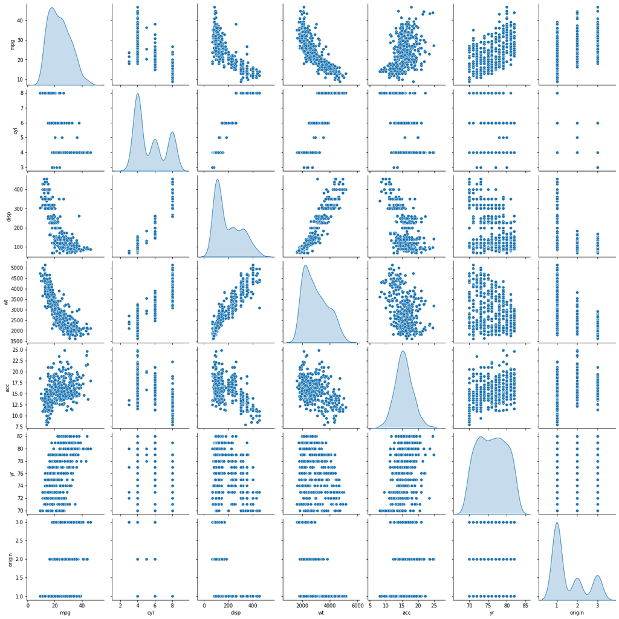

```python
sns.pairplot(carDF,diag_kind='kde')
plt.show()
```

**D. Visualize a scatterplot for ‘wt’ and ‘disp’. Datapoints should be distinguishable by ‘cyl’.**

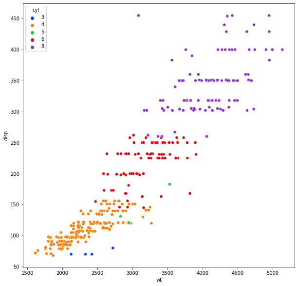

```python
plt.subplots(figsize=(10, 10))
plot = sns.scatterplot(x = carDF['wt'], y = carDF['disp'], hue = carDF['cyl'], palette= 'bright');
```

**E. Share insights for Q2.d.**

**Observation:**

Clearly, there is a positive correlation between wt and disp feature. Based on the number of cylinders, clearly there can be 3 possible clusters. From above graph, cyl 3, 4 can be combined whereas 5 and 6 can be combined into one group. There seems to be one outlier for cylinder value 8 too.

**F. Visualize a scatterplot for ‘wt’ and ’mpg’. Datapoints should be distinguishable by ‘cyl’.**

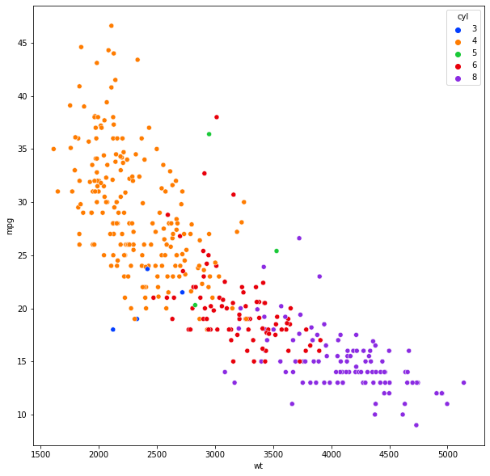

```python
plt.subplots(figsize=(10, 10))
plot = sns.scatterplot(x = carDF['wt'], y = carDF['mpg'], hue = carDF['cyl'], palette= 'bright');
```

**G. Share insights for Q2.f.**

**Observation:**

A negative correlation is seen between wt and mpg feature. Based on the number of cylinders, again there can be 3 possible clusters. Seems like cyl (3,4) and cyl (5,6) group may work here too.

**H. Check for unexpected values in all the features and datapoints with such values.**

```python
#Check unique values of each columns
print("Unique Values of Columns:\n")
for column in set(carDF.columns) - {'car_name'}:
    print('{:<20s} \t-  {}'.format(column,carDF[column].unique()))
```

```
Unique Values of Columns:

wt                   	-  [3504 3693 3436 3433 3449 4341 4354 4312 4425 3850 3563 3609 3761 3086
 2372 2833 2774 2587 2130 1835 2672 2430 2375 2234 2648 4615 4376 4382
 4732 2264 2228 2046 2634 3439 3329 3302 3288 4209 4464 4154 4096 4955
 4746 5140 2962 2408 3282 3139 2220 2123 2074 2065 1773 1613 1834 1955
 2278 2126 2254 2226 4274 4385 4135 4129 3672 4633 4502 4456 4422 2330
 3892 4098 4294 4077 2933 2511 2979 2189 2395 2288 2506 2164 2100 4100
 3988 4042 3777 4952 4363 4237 4735 4951 3821 3121 3278 2945 3021 2904
 1950 4997 4906 4654 4499 2789 2279 2401 2379 2124 2310 2472 2265 4082
 4278 1867 2158 2582 2868 3399 2660 2807 3664 3102 2875 2901 3336 2451
 1836 2542 3781 3632 3613 4141 4699 4457 4638 4257 2219 1963 2300 1649
 2003 2125 2108 2246 2489 2391 2000 3264 3459 3432 3158 4668 4440 4498
 4657 3907 3897 3730 3785 3039 3221 3169 2171 2639 2914 2592 2702 2223
 2545 1937 3211 2694 2957 2671 1795 2464 2572 2255 2202 4215 4190 3962
 3233 3353 3012 3085 2035 3651 3574 3645 3193 1825 1990 2155 2565 3150
 3940 3270 2930 3820 4380 4055 3870 3755 2045 1945 3880 4060 4140 4295
 3520 3425 3630 3525 4220 4165 4325 4335 1940 2740 2755 2051 2075 1985
 2190 2815 2600 2720 1800 2070 3365 3735 3570 3535 3155 2965 3430 3210
 3380 3070 3620 3410 3445 3205 4080 2560 2230 2515 2745 2855 2405 2830
 3140 2795 2135 3245 2990 2890 3265 3360 3840 3725 3955 3830 4360 4054
 3605 1925 1975 1915 2670 3530 3900 3190 3420 2200 2150 2020 2595 2700
 2556 2144 1968 2120 2019 2678 2870 3003 3381 2188 2711 2434 2110 2800
 2085 2335 2950 3250 1850 2145 1845 2910 2420 2500 2905 2290 2490 2635
 2620 2725 1755 1875 1760 2050 2215 2380 2320 2210 2350 2615 3230 3160
 2900 3415 3060 3465 2605 2640 2575 2525 2735 2865 3035 1980 2025 1970
 2160 2205 2245 1965 1995 3015 2585 2835 2665 2370 2790 2295 2625]
mpg                  	-  [18.  15.  16.  17.  14.  24.  22.  21.  27.  26.  25.  10.  11.   9.
 28.  19.  12.  13.  23.  30.  31.  35.  20.  29.  32.  33.  17.5 15.5
 14.5 22.5 24.5 18.5 29.5 26.5 16.5 31.5 36.  25.5 33.5 20.5 30.5 21.5
 43.1 36.1 32.8 39.4 19.9 19.4 20.2 19.2 25.1 20.6 20.8 18.6 18.1 17.7
 27.5 27.2 30.9 21.1 23.2 23.8 23.9 20.3 21.6 16.2 19.8 22.3 17.6 18.2
 16.9 31.9 34.1 35.7 27.4 25.4 34.2 34.5 31.8 37.3 28.4 28.8 26.8 41.5
 38.1 32.1 37.2 26.4 24.3 19.1 34.3 29.8 31.3 37.  32.2 46.6 27.9 40.8
 44.3 43.4 36.4 44.6 40.9 33.8 32.7 23.7 23.6 32.4 26.6 25.8 23.5 39.1
 39.  35.1 32.3 37.7 34.7 34.4 29.9 33.7 32.9 31.6 28.1 30.7 24.2 22.4
 34.  38.  44. ]
yr                   	-  [70 71 72 73 74 75 76 77 78 79 80 81 82]
cyl                  	-  [8 4 6 3 5]
acc                  	-  [12.  11.5 11.  10.5 10.   9.   8.5  8.   9.5 15.  15.5 16.  14.5 20.5
 17.5 12.5 14.  13.5 18.5 19.  13.  19.5 18.  17.  23.5 16.5 21.  16.9
 14.9 17.7 15.3 13.9 12.8 15.4 17.6 22.2 22.1 14.2 17.4 16.2 17.8 12.2
 16.4 13.6 15.7 13.2 21.9 16.7 12.1 14.8 18.6 16.8 13.7 11.1 11.4 18.2
 15.8 15.9 14.1 21.5 14.4 19.4 19.2 17.2 18.7 15.1 13.4 11.2 14.7 16.6
 17.3 15.2 14.3 20.1 24.8 11.3 12.9 18.8 18.1 17.9 21.7 23.7 19.9 21.8
 13.8 12.6 16.1 20.7 18.3 20.4 19.6 17.1 15.6 24.6 11.6]
origin               	-  [1 3 2]
disp                 	-  [307.  350.  318.  304.  302.  429.  454.  440.  455.  390.  383.  340.
 400.  113.  198.  199.  200.   97.  110.  107.  104.  121.  360.  140.
  98.  232.  225.  250.  351.  258.  122.  116.   79.   88.   71.   72.
  91.   97.5  70.  120.   96.  108.  155.   68.  114.  156.   76.   83.
  90.  231.  262.  134.  119.  115.  101.  305.   85.  130.  168.  111.
 260.  151.  146.   80.   78.  105.  131.  163.   89.  267.   86.  183.
 141.  173.  135.   81.  100.  145.  112.  181.  144. ]
hp                   	-  [130 165 150 140 198 220 215 225 190 170 160 95 97 85 88 46 87 90 113 200
 210 193 '?' 100 105 175 153 180 110 72 86 70 76 65 69 60 80 54 208 155
 112 92 145 137 158 167 94 107 230 49 75 91 122 67 83 78 52 61 93 148 129
 96 71 98 115 53 81 79 120 152 102 108 68 58 149 89 63 48 66 139 103 125
 133 138 135 142 77 62 132 84 64 74 116 82]
```

```python
carDF['hp'].value_counts()['?']
```

```
6
```

```python
#Using drop() to delete rows based on column value
carDF.drop(carDF[carDF['hp'] == '?'].index, inplace = True)
```

```python
carDF.shape
```

```
(390, 9)
```

```python
# hp is a numerical feature. Convert it to integer data type
carDF['hp'] = pd.to_numeric(carDF['hp'], errors = 'coerce')
```

**Observations:**

6 occurences of "?" removed from HP feature. No unexpected values found in any other feature.

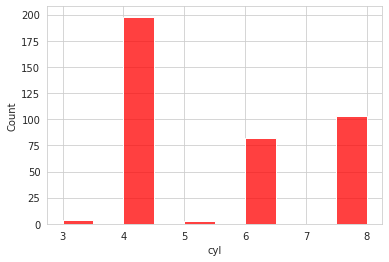

```python
# Check the distribution of cylinder.
sns.set_style('whitegrid')
sns.histplot(carDF['cyl'], kde = False, color ='red');
```

**Observation:**

From above plots, the instances of cyl 3 and 5 are very minimal. Also, from pairplot, it is safe to combine cyl 3 with 4 and similarly group 5 with 6.

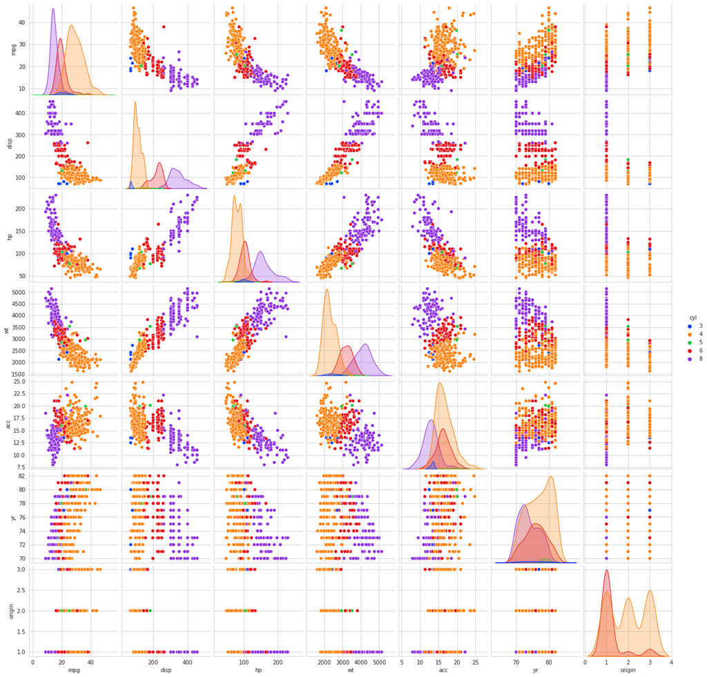

```python
sns.pairplot(carDF,diag_kind='kde', hue='cyl', palette = 'bright')
plt.show()
```

```python
# Lets create a new feature with 3,4 cylinders and 5,6 cylinders combined.
carDF['cylGroup'] = ''
carDF.cylGroup = np.where(carDF.cyl.isin([3,4]), "small_large",   carDF.cylGroup)
carDF.cylGroup = np.where(carDF.cyl.isin([5,6]), "highend",       carDF.cylGroup)
carDF.cylGroup = np.where(carDF.cyl.isin([8]),   "supercars",     carDF.cylGroup)
carDF.cylGroup = carDF.cylGroup.astype('category')
```

```python
carDF.head()
```

|  | car_name | mpg | cyl | disp | hp | wt | acc | yr | origin | cylGroup |
| --- | --- | --- | --- | --- | --- | --- | --- | --- | --- | --- |
| 0 | chevrolet chevelle malibu | 18.0 | 8 | 307.0 | 130 | 3504 | 12.0 | 70 | 1 | supercars |
| 1 | buick skylark 320 | 15.0 | 8 | 350.0 | 165 | 3693 | 11.5 | 70 | 1 | supercars |
| 2 | plymouth satellite | 18.0 | 8 | 318.0 | 150 | 3436 | 11.0 | 70 | 1 | supercars |
| 3 | amc rebel sst | 16.0 | 8 | 304.0 | 150 | 3433 | 12.0 | 70 | 1 | supercars |
| 4 | ford torino | 17.0 | 8 | 302.0 | 140 | 3449 | 10.5 | 70 | 1 | supercars |

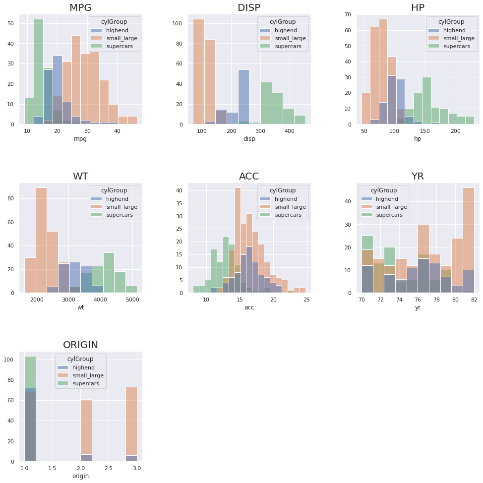

```python
import math
cols = carDF.columns.to_list()

# Skip car_name and cyl column as it is not needed
cols.remove('car_name')
cols.remove('cyl')
cols.remove('cylGroup')

# Derive the num of rows required for subplot display. Assume num of col in grid is 3.
ncol = len(cols)
nrow = math.ceil(ncol/3)
count = 1

fig, ax = plt.subplots(figsize=(15, 15))

for i in cols:
  sns.set(style="darkgrid")
  plt.subplot(nrow, 3, count)
  axes = sns.histplot(x = carDF[i], hue = carDF['cylGroup'])
  axes.set_ylabel('')
  axes.set_title(i.upper(),fontsize=20)
  count += 1

fig.tight_layout(pad=5.0)
plt.show();
```

```python
carDF.info()
```

```
<class 'pandas.core.frame.DataFrame'>
Int64Index: 390 entries, 0 to 395
Data columns (total 10 columns):
 #   Column    Non-Null Count  Dtype
---  ------    --------------  -----
 0   car_name  390 non-null    object
 1   mpg       390 non-null    float64
 2   cyl       390 non-null    int64
 3   disp      390 non-null    float64
 4   hp        390 non-null    int64
 5   wt        390 non-null    int64
 6   acc       390 non-null    float64
 7   yr        390 non-null    int64
 8   origin    390 non-null    int64
 9   cylGroup  390 non-null    category
dtypes: category(1), float64(3), int64(5), object(1)
memory usage: 39.1+ KB
```

```python
# One-hot encoding categorical features cylgroup and Origin
carDF_encoded = pd.get_dummies(data=carDF, columns=['cylGroup', 'origin'],drop_first= True)
```

```python
carDF_encoded.columns
```

```
Index(['car_name', 'mpg', 'cyl', 'disp', 'hp', 'wt', 'acc', 'yr',
       'cylGroup_small_large', 'cylGroup_supercars', 'origin_2', 'origin_3'],
      dtype='object')
```

```python
cols_to_drop = ['car_name','cyl']
carDF_Final = carDF_encoded.drop(cols_to_drop, axis=1)
```

## **3. Clustering**

**A. Apply K-Means clustering for 2 to 10 clusters**

```python
carDF_Final.info()
```

```
<class 'pandas.core.frame.DataFrame'>
Int64Index: 390 entries, 0 to 395
Data columns (total 10 columns):
 #   Column                Non-Null Count  Dtype
---  ------                --------------  -----
 0   mpg                   390 non-null    float64
 1   disp                  390 non-null    float64
 2   hp                    390 non-null    int64
 3   wt                    390 non-null    int64
 4   acc                   390 non-null    float64
 5   yr                    390 non-null    int64
 6   cylGroup_small_large  390 non-null    uint8
 7   cylGroup_supercars    390 non-null    uint8
 8   origin_2              390 non-null    uint8
 9   origin_3              390 non-null    uint8
dtypes: float64(3), int64(3), uint8(4)
memory usage: 31.0 KB
```

```python
## Scale the data
X = carDF_Final.apply(zscore)
```

```python
# Using the elbow method to find  the optimal number of clusters
from sklearn.cluster import KMeans

wcss=[]

for i in range (2,11):
    kmeans=KMeans(n_clusters=i,init='k-means++', max_iter=100, random_state=0)
    kmeans.fit(X)
    wcss.append(kmeans.inertia_)
```

**B. Plot a visual and find elbow point**

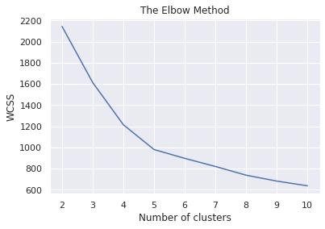

```python
plt.plot(range(2,11),wcss)
plt.title('The Elbow Method')
plt.xlabel('Number of clusters')
plt.ylabel('WCSS')
plt.show();
```

**C. On the above visual, highlight which are the possible Elbow points.**

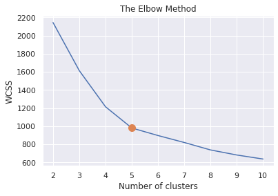

```python
plt.plot(range(2,11),wcss)
plt.title('The Elbow Method')
plt.xlabel('Number of clusters')
plt.ylabel('WCSS')
x = [5]
y = [wcss[3]]
plt.plot(x, y, "o", markersize = 10)
plt.show()
```

**Observations:**

From the above elbow method, K value 5 seem like possible elbow point. However, from our pair plot analysis, 3 clusters looked apt too. So we will analyse both 3 and 5 as optimal number of clusters and compare.

**D. Train a K-means clustering model once again on the optimal number of clusters.**

```python
from sklearn.metrics import silhouette_samples, silhouette_score
from mpl_toolkits.mplot3d import Axes3D

def create_clusters(n):
  # Set the value given as input
  kmeans = KMeans(n_clusters=n, init='k-means++')

  X_predict = kmeans.fit_predict(X)

  centroid = kmeans.cluster_centers_

  print("\nCentroids found at:")
  print(centroid)
  plt.rcParams['figure.figsize'] = [14, 7]
  plt.rc('font', size=12)

  labels=kmeans.labels_.astype(float)

  plt.scatter(X['wt'], X['disp'], c= labels, edgecolor = 'black')
  plt.scatter(centroid[:,3], centroid[:,1], c='green', s = 100)
  plt.xlabel('Weight')
  plt.ylabel('Displacement')

  print('\nSilhouette Score for K Value :' , n)
  print(silhouette_score(X,labels))

  return kmeans, X_predict
```

```
Centroids found at:
[[-1.12240579  1.46007814  1.45268236  1.35854732 -1.02827076 -0.61482831
  -1.03656552  1.66925366 -0.45954339 -0.50400327]
 [ 0.5819168  -0.67541331 -0.61335493 -0.64835111  0.35049089  0.55193903
   0.96472435 -0.59907013 -0.45954339 -0.50400327]
 [ 0.59838262 -0.83580409 -0.67695651 -0.6974929   0.474593   -0.10035255
   0.84156805 -0.59907013  2.1760731  -0.50400327]
 [-0.48522943  0.30006338 -0.08518623  0.3099774   0.3525969  -0.0319022
  -1.03656552 -0.48705414 -0.36192796 -0.44256827]
 [ 0.93450058 -0.89087661 -0.66500209 -0.9114213   0.2409939   0.42133952
   0.86076124 -0.59907013 -0.45954339  1.98411412]]

Silhouette Score for K Value : 5
0.40703822314279836
```

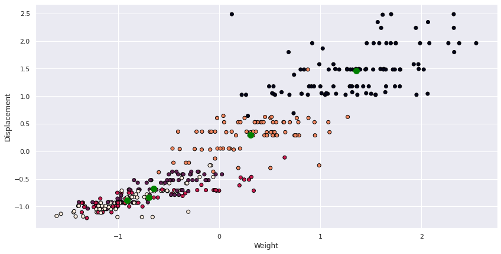

```python
# Lets try with k = 5
kmeans_5, X_predict = create_clusters(5)
```

**Observation:**

Bottom cluster looks crowded and overlapping with k-means 5 cluster model. Let us try with 3 clusters.

```
Centroids found at:
[[-1.12240579  1.46007814  1.45268236  1.35854732 -1.02827076 -0.61482831
  -1.03656552  1.66925366 -0.45954339 -0.50400327]
 [ 0.73149313 -0.81714373 -0.6734133  -0.78260773  0.36790499  0.28414775
   0.94510386 -0.59907013  0.354397    0.38635247]
 [-0.43800488  0.25459294 -0.07401425  0.28914703  0.30742745  0.03335473
  -1.03656552 -0.49477938 -0.30807118 -0.33240896]]

Silhouette Score for K Value : 3
0.34291317773770735
```

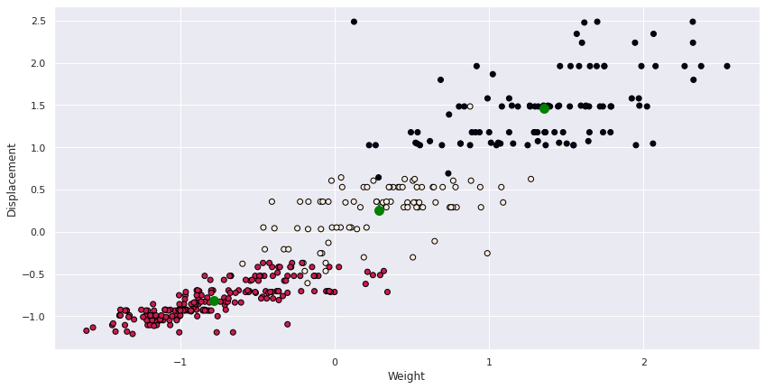

```python
# Lets try with k = 3
kmeans_3, X_predict = create_clusters(3)
```

**E. Add a new feature in the DataFrame which will have labels based upon cluster value.**

```python
# get unique values and counts of each value
unique, counts = np.unique(kmeans_3.labels_, return_counts=True)

# display unique values and counts side by side
print(np.asarray((unique, counts)))
```

```
[[  0   1   2]
 [ 99 204  87]]
```

```python
## creating a new dataframe only for labels and converting it into categorical variable
map_labels = {0: "high_end", 2: "sports", 1: "small_large"}
df_labels = pd.DataFrame(kmeans_3.labels_ , columns = list(['CarSegment']))
df_labels['CarSegment']=df_labels['CarSegment'].map(map_labels)
df_labels['CarSegment'] = df_labels['CarSegment'].astype('category')
```

```python
# Joining the label dataframe with the data frame.
X_labeled = X.join(df_labels)
```

```python
X_labeled['CarSegment'].value_counts()
```

```
small_large    201
high_end        99
sports          84
Name: CarSegment, dtype: int64
```

**F. Plot a visual and color the datapoints based upon clusters.**

```python
X_labeled.sample(10)
```

|  | mpg | disp | hp | wt | acc | yr | cylGroup_small_large | cylGroup_supercars | origin_2 | origin_3 | CarSegment |
| --- | --- | --- | --- | --- | --- | --- | --- | --- | --- | --- | --- |
| 115 | -1.082018 | 1.483612 | 1.050211 | 1.297606 | -0.924648 | -0.807002 | -1.036566 | 1.669254 | -0.459543 | -0.504003 | high_end |
| 71 | -0.569400 | -1.189982 | -0.195746 | -0.763668 | -0.743399 | -1.078790 | 0.964724 | -0.599070 | -0.459543 | 1.984114 | high_end |
| 267 | 0.481466 | -0.722103 | -0.195746 | -0.798964 | -0.308402 | 0.551939 | 0.964724 | -0.599070 | -0.459543 | 1.984114 | small_large |
| 331 | 0.814668 | -1.008559 | -1.104256 | -1.334283 | -0.090903 | 1.095515 | 0.964724 | -0.599070 | 2.176073 | -0.504003 | small_large |
| 142 | 0.327681 | -1.104045 | -0.974469 | -1.195453 | -0.018404 | -0.535214 | 0.964724 | -0.599070 | 2.176073 | -0.504003 | small_large |
| 41 | -1.210172 | 1.178058 | 1.179998 | 1.314077 | -0.924648 | -1.350578 | -1.036566 | 1.669254 | -0.459543 | -0.504003 | high_end |
| 84 | 0.455835 | -0.932171 | -0.429363 | -1.034269 | 0.344094 | -1.078790 | 0.964724 | -0.599070 | -0.459543 | 1.984114 | high_end |
| 226 | -0.569400 | 0.290043 | -0.117873 | 0.765816 | 0.779091 | 0.280151 | -1.036566 | -0.599070 | -0.459543 | -0.504003 | high_end |
| 23 | 0.327681 | -0.703006 | 0.219573 | -0.876614 | -1.105897 | -1.622366 | 0.964724 | -0.599070 | 2.176073 | -0.504003 | small_large |
| 215 | 1.032530 | -0.922622 | -0.948511 | -1.098978 | 1.069089 | 0.280151 | 0.964724 | -0.599070 | -0.459543 | 1.984114 | small_large |

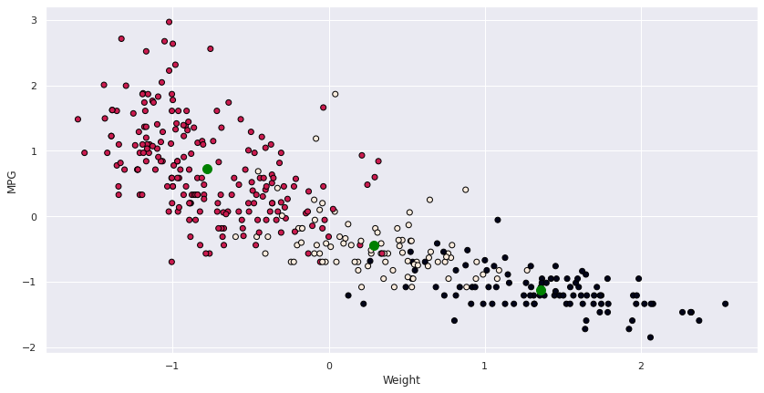

```python
plt.rcParams['figure.figsize'] = [14, 7]
plt.rc('font', size=12)
labels=kmeans_3.labels_.astype(float)
plt.scatter(X_labeled['wt'], X_labeled['mpg'], c= labels, edgecolor = 'black')
plt.scatter(kmeans_3.cluster_centers_[:,3], kmeans_3.cluster_centers_[:,0], c='green', s = 100)
plt.xlabel('Weight')
plt.ylabel('MPG')
plt.show();
```

**G. Pass a new DataPoint and predict which cluster it belongs to.**

```python
# Generate test data. Let us copy few rows from train data and modify them slightly.
test_df = X_labeled.sample(n=10)
test_df.drop(columns=['CarSegment'], inplace = True)
```

```python
test_df += 1
test_df
```

|  | mpg | disp | hp | wt | acc | yr | cylGroup_small_large | cylGroup_supercars | origin_2 | origin_3 |
| --- | --- | --- | --- | --- | --- | --- | --- | --- | --- | --- |
| 153 | 0.302446 | 1.528757 | 1.011914 | 1.564630 | 1.162845 | 0.736575 | -0.036566 | 0.400930 | 0.540457 | 0.495997 |
| 327 | 1.840299 | 0.535708 | 0.025531 | 1.318736 | 3.265331 | 2.095515 | 1.964724 | 0.400930 | 3.176073 | 0.495997 |
| 311 | 2.763011 | -0.037205 | -0.026383 | -0.129568 | 1.307844 | 2.095515 | 1.964724 | 0.400930 | 0.540457 | 2.984114 |
| 365 | 1.583990 | 0.211057 | 0.570637 | 0.559877 | 2.467836 | 2.639092 | 1.964724 | 0.400930 | 0.540457 | 0.495997 |
| 319 | 2.737380 | 0.277897 | 0.674467 | 0.358691 | 0.800347 | 2.095515 | 1.964724 | 0.400930 | 0.540457 | 2.984114 |
| 273 | 0.597201 | 0.392480 | 0.959999 | 0.824595 | 1.126595 | 1.551939 | -0.036566 | 0.400930 | 3.176073 | 0.495997 |
| 162 | -0.082018 | 1.605145 | 1.141701 | 1.883468 | 2.250338 | 0.736575 | -0.036566 | 0.400930 | 0.540457 | 0.495997 |
| 211 | 0.110214 | 2.483612 | 2.958721 | 2.648210 | -0.250896 | 1.008363 | -0.036566 | 2.669254 | 0.540457 | 0.495997 |
| 223 | -0.082018 | 2.025282 | 1.660850 | 2.548206 | 0.764098 | 1.280151 | -0.036566 | 2.669254 | 0.540457 | 0.495997 |
| 243 | 3.519122 | 0.000989 | -0.467660 | -0.169569 | 3.156582 | 1.551939 | 1.964724 | 0.400930 | 3.176073 | 0.495997 |

```python
X_predict = kmeans_3.predict(test_df)
```

```python
X_predict
```

```
array([2, 1, 1, 1, 1, 1, 2, 0, 0, 1], dtype=int32)
```

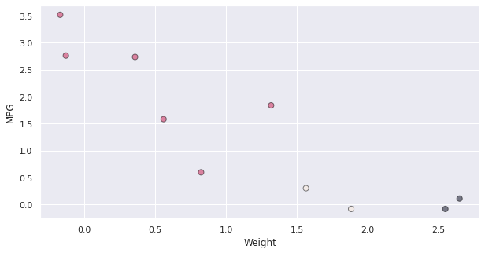

```python
plt.rcParams['figure.figsize'] = [10, 5]
plt.rc('font', size=12)
plt.scatter(test_df['wt'], test_df['mpg'], c= X_predict.astype(float), edgecolor='black', s=50, alpha=0.5);
plt.xlabel('Weight')
plt.ylabel('MPG')
plt.show();
```

# **PART B**

• DOMAIN: Automobile

• CONTEXT: The purpose is to classify a given silhouette as one of three types of vehicle, using a set of features extracted from the silhouette. The vehicle may be viewed from one of many different angles.

• DATA DESCRIPTION: The data contains features extracted from the silhouette of vehicles in different angles. Four "Corgie" model vehicles were used for the experiment: a double decker bus, Cheverolet van, Saab 9000 and an Opel Manta 400 cars. This particular combination of vehicles was chosen with the expectation that the bus, van and either one of the cars would be readily distinguishable, but it would be more difficult to distinguish between the cars.

• All the features are numeric i.e. geometric features extracted from the silhouette.

• PROJECT OBJECTIVE: Apply dimensionality reduction technique – PCA and train a model and compare relative results.

## **1. Data Understanding & Cleaning:**

```python
# Import all the necessary libraries.
import pandas as pd
import numpy as np
import seaborn as sns
import matplotlib.pyplot as plt
%matplotlib inline
```

**A. Read ‘vehicle.csv’ and save as DataFrame.**

```python
vehicle_df = pd.read_csv("vehicle.csv")
vehicle_df
```

|  | compactness | circularity | distance_circularity | radius_ratio | pr.axis_aspect_ratio | max.length_aspect_ratio | scatter_ratio | elongatedness | pr.axis_rectangularity | max.length_rectangularity | scaled_variance | scaled_variance.1 | scaled_radius_of_gyration | scaled_radius_of_gyration.1 | skewness_about | skewness_about.1 | skewness_about.2 | hollows_ratio | class |
| --- | --- | --- | --- | --- | --- | --- | --- | --- | --- | --- | --- | --- | --- | --- | --- | --- | --- | --- | --- |
| 0 | 95 | 48.0 | 83.0 | 178.0 | 72.0 | 10 | 162.0 | 42.0 | 20.0 | 159 | 176.0 | 379.0 | 184.0 | 70.0 | 6.0 | 16.0 | 187.0 | 197 | van |
| 1 | 91 | 41.0 | 84.0 | 141.0 | 57.0 | 9 | 149.0 | 45.0 | 19.0 | 143 | 170.0 | 330.0 | 158.0 | 72.0 | 9.0 | 14.0 | 189.0 | 199 | van |
| 2 | 104 | 50.0 | 106.0 | 209.0 | 66.0 | 10 | 207.0 | 32.0 | 23.0 | 158 | 223.0 | 635.0 | 220.0 | 73.0 | 14.0 | 9.0 | 188.0 | 196 | car |
| 3 | 93 | 41.0 | 82.0 | 159.0 | 63.0 | 9 | 144.0 | 46.0 | 19.0 | 143 | 160.0 | 309.0 | 127.0 | 63.0 | 6.0 | 10.0 | 199.0 | 207 | van |
| 4 | 85 | 44.0 | 70.0 | 205.0 | 103.0 | 52 | 149.0 | 45.0 | 19.0 | 144 | 241.0 | 325.0 | 188.0 | 127.0 | 9.0 | 11.0 | 180.0 | 183 | bus |
| ... | ... | ... | ... | ... | ... | ... | ... | ... | ... | ... | ... | ... | ... | ... | ... | ... | ... | ... | ... |
| 841 | 93 | 39.0 | 87.0 | 183.0 | 64.0 | 8 | 169.0 | 40.0 | 20.0 | 134 | 200.0 | 422.0 | 149.0 | 72.0 | 7.0 | 25.0 | 188.0 | 195 | car |
| 842 | 89 | 46.0 | 84.0 | 163.0 | 66.0 | 11 | 159.0 | 43.0 | 20.0 | 159 | 173.0 | 368.0 | 176.0 | 72.0 | 1.0 | 20.0 | 186.0 | 197 | van |
| 843 | 106 | 54.0 | 101.0 | 222.0 | 67.0 | 12 | 222.0 | 30.0 | 25.0 | 173 | 228.0 | 721.0 | 200.0 | 70.0 | 3.0 | 4.0 | 187.0 | 201 | car |
| 844 | 86 | 36.0 | 78.0 | 146.0 | 58.0 | 7 | 135.0 | 50.0 | 18.0 | 124 | 155.0 | 270.0 | 148.0 | 66.0 | 0.0 | 25.0 | 190.0 | 195 | car |
| 845 | 85 | 36.0 | 66.0 | 123.0 | 55.0 | 5 | 120.0 | 56.0 | 17.0 | 128 | 140.0 | 212.0 | 131.0 | 73.0 | 1.0 | 18.0 | 186.0 | 190 | van |

846 rows × 19 columns

```python
vehicle_df.info()
```

```
<class 'pandas.core.frame.DataFrame'>
RangeIndex: 846 entries, 0 to 845
Data columns (total 19 columns):
 #   Column                       Non-Null Count  Dtype
---  ------                       --------------  -----
 0   compactness                  846 non-null    int64
 1   circularity                  841 non-null    float64
 2   distance_circularity         842 non-null    float64
 3   radius_ratio                 840 non-null    float64
 4   pr.axis_aspect_ratio         844 non-null    float64
 5   max.length_aspect_ratio      846 non-null    int64
 6   scatter_ratio                845 non-null    float64
 7   elongatedness                845 non-null    float64
 8   pr.axis_rectangularity       843 non-null    float64
 9   max.length_rectangularity    846 non-null    int64
 10  scaled_variance              843 non-null    float64
 11  scaled_variance.1            844 non-null    float64
 12  scaled_radius_of_gyration    844 non-null    float64
 13  scaled_radius_of_gyration.1  842 non-null    float64
 14  skewness_about               840 non-null    float64
 15  skewness_about.1             845 non-null    float64
 16  skewness_about.2             845 non-null    float64
 17  hollows_ratio                846 non-null    int64
 18  class                        846 non-null    object
dtypes: float64(14), int64(4), object(1)
memory usage: 125.7+ KB
```

```python
# Feature class attribute should be a category. Change it.
vehicle_df['class']=vehicle_df['class'].astype('category')
```

```python
#Analyze the distribution of the dataset
vehicle_df.describe().T
```

|  | count | mean | std | min | 25% | 50% | 75% | max |
| --- | --- | --- | --- | --- | --- | --- | --- | --- |
| compactness | 846.0 | 93.678487 | 8.234474 | 73.0 | 87.00 | 93.0 | 100.0 | 119.0 |
| circularity | 841.0 | 44.828775 | 6.152172 | 33.0 | 40.00 | 44.0 | 49.0 | 59.0 |
| distance_circularity | 842.0 | 82.110451 | 15.778292 | 40.0 | 70.00 | 80.0 | 98.0 | 112.0 |
| radius_ratio | 840.0 | 168.888095 | 33.520198 | 104.0 | 141.00 | 167.0 | 195.0 | 333.0 |
| pr.axis_aspect_ratio | 844.0 | 61.678910 | 7.891463 | 47.0 | 57.00 | 61.0 | 65.0 | 138.0 |
| max.length_aspect_ratio | 846.0 | 8.567376 | 4.601217 | 2.0 | 7.00 | 8.0 | 10.0 | 55.0 |
| scatter_ratio | 845.0 | 168.901775 | 33.214848 | 112.0 | 147.00 | 157.0 | 198.0 | 265.0 |
| elongatedness | 845.0 | 40.933728 | 7.816186 | 26.0 | 33.00 | 43.0 | 46.0 | 61.0 |
| pr.axis_rectangularity | 843.0 | 20.582444 | 2.592933 | 17.0 | 19.00 | 20.0 | 23.0 | 29.0 |
| max.length_rectangularity | 846.0 | 147.998818 | 14.515652 | 118.0 | 137.00 | 146.0 | 159.0 | 188.0 |
| scaled_variance | 843.0 | 188.631079 | 31.411004 | 130.0 | 167.00 | 179.0 | 217.0 | 320.0 |
| scaled_variance.1 | 844.0 | 439.494076 | 176.666903 | 184.0 | 318.00 | 363.5 | 587.0 | 1018.0 |
| scaled_radius_of_gyration | 844.0 | 174.709716 | 32.584808 | 109.0 | 149.00 | 173.5 | 198.0 | 268.0 |
| scaled_radius_of_gyration.1 | 842.0 | 72.447743 | 7.486190 | 59.0 | 67.00 | 71.5 | 75.0 | 135.0 |
| skewness_about | 840.0 | 6.364286 | 4.920649 | 0.0 | 2.00 | 6.0 | 9.0 | 22.0 |
| skewness_about.1 | 845.0 | 12.602367 | 8.936081 | 0.0 | 5.00 | 11.0 | 19.0 | 41.0 |
| skewness_about.2 | 845.0 | 188.919527 | 6.155809 | 176.0 | 184.00 | 188.0 | 193.0 | 206.0 |
| hollows_ratio | 846.0 | 195.632388 | 7.438797 | 181.0 | 190.25 | 197.0 | 201.0 | 211.0 |

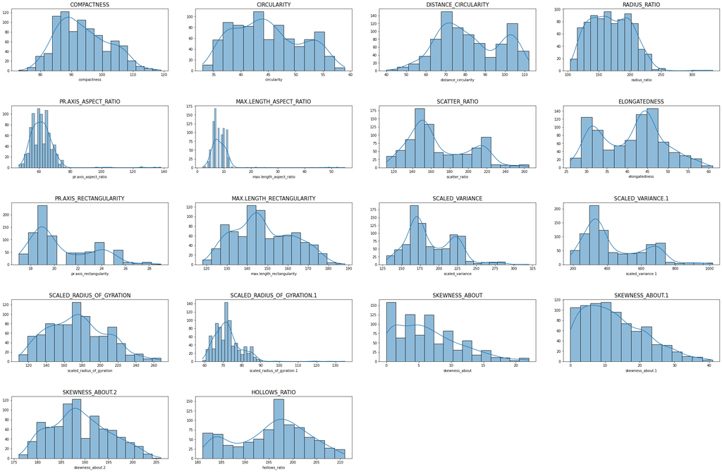

```python
import math

numerical_cols = vehicle_df.select_dtypes(['int64','float64']).columns.to_list()

# Derive the num of rows required for subplot display. Assume num of col in grid is 4.
ncol = len(numerical_cols)
nrow = math.ceil(ncol/4)

# Set the Color Map for Pie Chart
cmap = plt.cm.prism
cmap = plt.get_cmap('Accent')
my_colors = [cmap(i) for i in np.linspace(0, 1, 8)]
fig = plt.figure(figsize=(30, 20))

# Counter to point at the location in grid
count = 1

for i in numerical_cols:
  plt.subplot(nrow, 4, count)
  axes = sns.histplot(data=vehicle_df, x = vehicle_df[i], kde=True)
  axes.set_ylabel('')
  axes.set_title(i.upper(),fontsize=15)
  count += 1

fig.tight_layout(pad=5.0)
plt.show();
```

**Observation:**

Right Skewed with potential outliers:

- radius_ratio
- pr.axis_aspect_ratio
- max.length_aspect_ratio
- scaled_variance
- scaled_variance.1
- scaled_radius_of_gyration.1
- skewness_about
- skewness_about.1

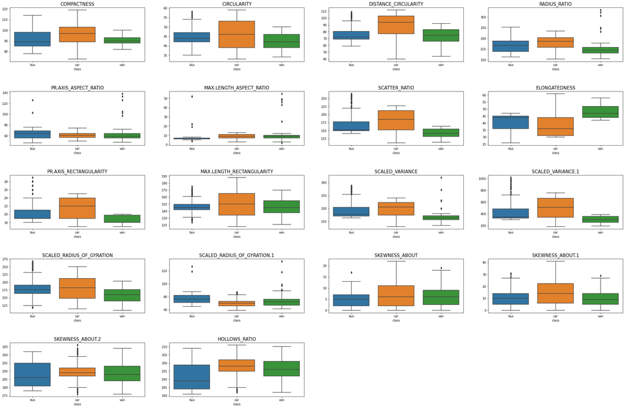

```python
fig, ax = plt.subplots(figsize=(30, 20))

# Counter to point at the location in grid
count = 1

for i in numerical_cols:
  plt.subplot(nrow, 4, count)
  axes = sns.boxplot(y = vehicle_df[i], x = "class", data = vehicle_df)
  axes.set_ylabel('')
  axes.set_title(i.upper(),fontsize=15)
  count += 1

fig.tight_layout(pad=5.0)
plt.show();
```

**Observations:**

Outliers are seen in many features like radius_ratio, pr.axis_aspect_ratio, max.length_aspect_ratiom, scaled_radius_of_gyration.1, scaled_variance.1, scaled_variance, skewness_about, skewness_about.1, etc.